# Exploring Red Wine Quality Analysis by Sakshi Dubey

## Intrduction:

Wine industry shows a recent growth spurt as social drinking is on the rise. The price of wine depends on a rather abstract concept of wine appreciation by wine tasters, opinion among whom may have a high degree of variability. Pricing of wine depends on such a volatile factor to some extent. Another key factor in wine certification and quality assessment is physicochemical tests which are laboratory-based and takes into account factors like acidity, pH level, presence of sugar and other chemical properties. For the wine market, it would be of interest if human quality of tasting can be related to the chemical properties of wine so that certification and quality assessment and assurance process is more controlled.

This project is part of Data Analyst Nanodegree. We will first load all the packages that we are going to use in this project.

Our next step is to load the data.I have taken ‘wineQualityReds’ data for my analysis.

## About the data

In this project I will analyse and explore the data set on red wine quality and its various properties. The main objective is to find which chemical properties influence the quality of red wine. How much it is helpful to take? For this project I have used statistical program, R and drawn interesting relationships from the data given. I have plotted various graphs for the data set.

Let’s look at interesting plots and analysis.

## Summary

Here I ran some of the basic commands. From this I have found out the schema and structure of the data set. We can see a nice result here about each variable.

```
## 'data.frame':    1599 obs. of  13 variables:
##  $ X                   : int  1 2 3 4 5 6 7 8 9 10 ...
##  $ fixed.acidity       : num  7.4 7.8 7.8 11.2 7.4 7.4 7.9 7.3 7.8 7.5 ...
##  $ volatile.acidity    : num  0.7 0.88 0.76 0.28 0.7 0.66 0.6 0.65 0.58 0.5 ...
##  $ citric.acid         : num  0 0 0.04 0.56 0 0 0.06 0 0.02 0.36 ...
##  $ residual.sugar      : num  1.9 2.6 2.3 1.9 1.9 1.8 1.6 1.2 2 6.1 ...
##  $ chlorides           : num  0.076 0.098 0.092 0.075 0.076 0.075 0.069 0.065 0.073 0.071 ...
##  $ free.sulfur.dioxide : num  11 25 15 17 11 13 15 15 9 17 ...
##  $ total.sulfur.dioxide: num  34 67 54 60 34 40 59 21 18 102 ...
##  $ density             : num  0.998 0.997 0.997 0.998 0.998 ...
##  $ pH                  : num  3.51 3.2 3.26 3.16 3.51 3.51 3.3 3.39 3.36 3.35 ...
##  $ sulphates           : num  0.56 0.68 0.65 0.58 0.56 0.56 0.46 0.47 0.57 0.8 ...
##  $ alcohol             : num  9.4 9.8 9.8 9.8 9.4 9.4 9.4 10 9.5 10.5 ...
##  $ quality             : int  5 5 5 6 5 5 5 7 7 5 ...
```

```
##        X          fixed.acidity   volatile.acidity  citric.acid
##  Min.   :   1.0   Min.   : 4.60   Min.   :0.1200   Min.   :0.000
##  1st Qu.: 400.5   1st Qu.: 7.10   1st Qu.:0.3900   1st Qu.:0.090
##  Median : 800.0   Median : 7.90   Median :0.5200   Median :0.260
##  Mean   : 800.0   Mean   : 8.32   Mean   :0.5278   Mean   :0.271
##  3rd Qu.:1199.5   3rd Qu.: 9.20   3rd Qu.:0.6400   3rd Qu.:0.420
##  Max.   :1599.0   Max.   :15.90   Max.   :1.5800   Max.   :1.000
##  residual.sugar     chlorides       free.sulfur.dioxide
##  Min.   : 0.900   Min.   :0.01200   Min.   : 1.00
##  1st Qu.: 1.900   1st Qu.:0.07000   1st Qu.: 7.00
##  Median : 2.200   Median :0.07900   Median :14.00
##  Mean   : 2.539   Mean   :0.08747   Mean   :15.87
##  3rd Qu.: 2.600   3rd Qu.:0.09000   3rd Qu.:21.00
##  Max.   :15.500   Max.   :0.61100   Max.   :72.00
##  total.sulfur.dioxide    density             pH          sulphates
##  Min.   :  6.00       Min.   :0.9901   Min.   :2.740   Min.   :0.3300
##  1st Qu.: 22.00       1st Qu.:0.9956   1st Qu.:3.210   1st Qu.:0.5500
##  Median : 38.00       Median :0.9968   Median :3.310   Median :0.6200
##  Mean   : 46.47       Mean   :0.9967   Mean   :3.311   Mean   :0.6581
##  3rd Qu.: 62.00       3rd Qu.:0.9978   3rd Qu.:3.400   3rd Qu.:0.7300
##  Max.   :289.00       Max.   :1.0037   Max.   :4.010   Max.   :2.0000
##     alcohol         quality
##  Min.   : 8.40   Min.   :3.000
##  1st Qu.: 9.50   1st Qu.:5.000
##  Median :10.20   Median :6.000
##  Mean   :10.42   Mean   :5.636
##  3rd Qu.:11.10   3rd Qu.:6.000
##  Max.   :14.90   Max.   :8.000
```

I have looked at the summary of alcohol and pH and obtained the following results:

```
##    Min. 1st Qu.  Median    Mean 3rd Qu.    Max.
##    8.40    9.50   10.20   10.42   11.10   14.90
```

```
##    Min. 1st Qu.  Median    Mean 3rd Qu.    Max.
##   2.740   3.210   3.310   3.311   3.400   4.010
```

But we are interested more on the quality of red wine. So let’s look at the summary of the red wine.

We can see the minimum value, 1st Quartile, Median, Mean, 3rd Quartile and Maximum value.

```
##    Min. 1st Qu.  Median    Mean 3rd Qu.    Max.
##   3.000   5.000   6.000   5.636   6.000   8.000
```

```
##    Min. 1st Qu.  Median    Mean 3rd Qu.    Max.
##   3.000   5.000   6.000   5.636   6.000   8.000
```

```
##
##   3   4   5   6   7   8
##  10  53 681 638 199  18
```

```
##  Ord.factor w/ 6 levels "3"<"4"<"5"<"6"<..: 3 3 3 4 3 3 3 5 5 3 ...
```

## Observations:

- We can see that there are **1599** observations of 13 numeric variables.
- It seems that **X** is a unique identifier in the data set.
- We noticed that there is ordered, categorical and discrete variable in the data set **quality**. It is on a 0-10 scale and was rated by atleast 3 wine experts.
- We can see the summary of **quality** variable. It’s values ranges from 3 to 8 with mean of 5.636 and median of 6.0
- All the other variables seems to be continuous with the exception of **.sulphur.dioxide** suffixes.
- From the other observations we can see that **fixed.acidity**~**volatile.acidity** and **free.sulfur.dioxide**~ **total.sulphur.dioxide** may possibly by dependent, subsets of each other.

# Univariate Plots Section

Before moving to the univariate analysis part,let’s look at graphs of all the 12 variables.

I have plotted the simple histogram plots for each variable. From the graphs we can differentiate that quality variable is discrete while the rest of the variables are continuous.

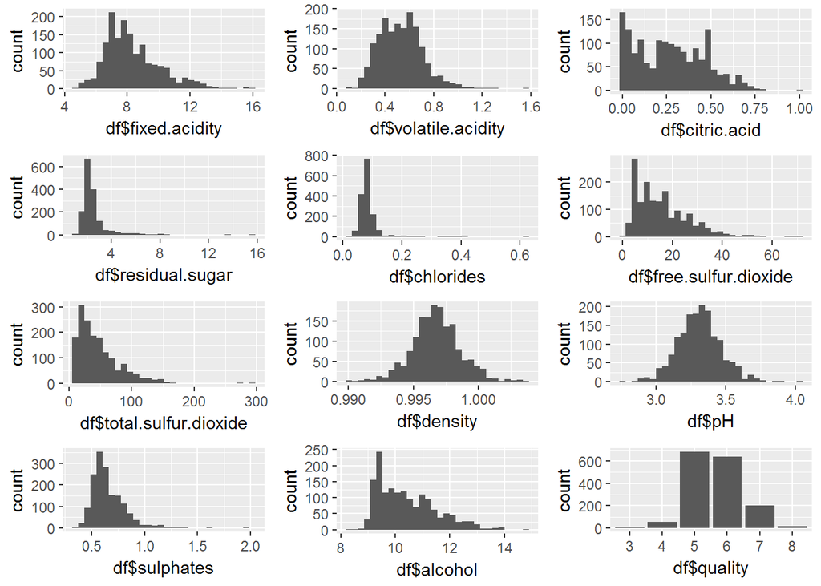

Now moving on to the univariate analysis section.

# Univariate Analysis

### 1.1 Wine Quality

As I mentioned earlier that my aim is to focus mainly on the quality of red wine. So continuing ahead, I have classified the rating of red wine on 3 categories: bad,average and good.

As we can look above at the summary of red wine quality, it has discrete range of only 3-8, we can roughly see that there is some amount of normal distribution. A large variety of wines examined received ratings of 5 or 6 and only few of them received 3, 4 and 8. We can not do much more in the histograms as increasing or decreasing the bin sizes will distort the data.

I have classified another categorical variable on the basis of given ratings and distribution of wine quality. I have classified wines as bad on rating (0 to 4), average on rating (5 or 6) and good on rating (7 to 10 ).

```
##     bad average    good
##      63    1319     217
```

From the above result we can see the total count of each categories of wine. As compared to good and average quality wines the count of bad quality wine is less.

This can also be seen in the graph(histogram) below:

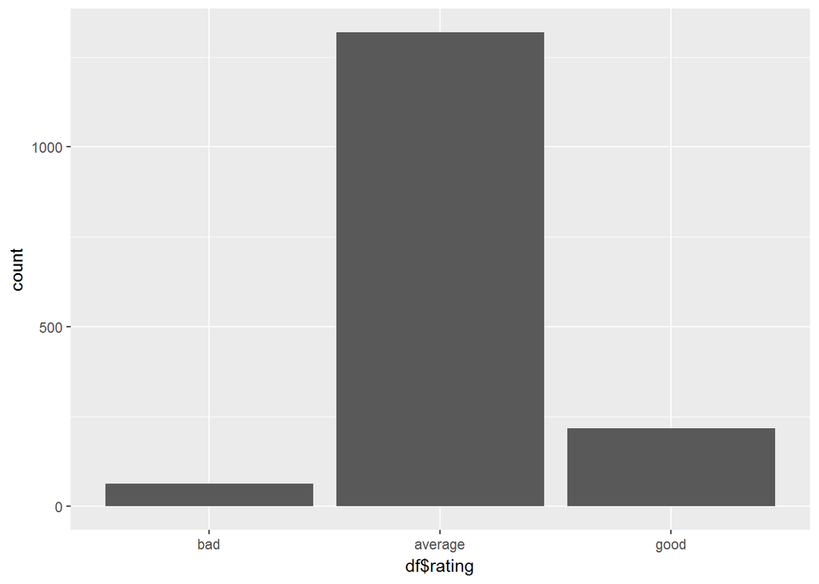